# Project proposal

Daytonna Anderson

```r
library(tidyverse)
library(janitor)
library(broom)
library(DATAstudio)
```

The data used in this analysis comes from the [`wildfire` dataset](https://r-packages.io/datasets/wildfire) included in the `DATAstudio` package in R. This dataset compiles records of wildfire events in Portugal, showing the amount of area burned (in hectares) for wildfires in Portugal, and then accompanied by Canadian Forest Fire Weather Index System Indices (CFFWIS). This data was originally collected from the monitoring systems and environmental observation networks. The goal for this project is to investigate how environmental factors influence wildfire behavior, specifically focusing on burned area.

Each row in this dataset represents a day. The dataset includes a primary response variable, `burnt_area`,which represents the total area burned per day. Since this data is taken on a national level, the analysis focuses on large-scale environmental influences on wildfire activity, rather than individual fire events.

The dataset also includes predictor variables that influence and describe fire weather and fuel conditions:

Fire Weather Index (`fwi`), Buildup Index (`bui`), Initial Spread Index (`isi`), Fine Fuel Moisture Code (`ffmc`), Duff Moisture Code (`dmc`), Drought Code (`dc`), and `day`, `month`, `year`.

## 1. Data

This data is under a package in R Studio:

```r
data("wildfire")

wildfire <- wildfire %>%
  clean_names()

glimpse(wildfire)
```

```
## Rows: 14,609
## Columns: 11
## $ burnt_area <dbl> 0, 0, 0, 0, 0, 0, 0, 0, 0, 0, 0, 0, 0, 0, 0, 0, 0, 0, 0, 0,…
## $ dsr        <dbl> 0.21199875, 0.30435486, 0.20406335, 0.19731392, 0.20655645,…
## $ fwi        <dbl> 1.9933842, 2.6409558, 2.1545397, 2.1686053, 2.1404615, 2.55…
## $ bui        <dbl> 12.415579, 13.011121, 13.666483, 14.223325, 14.377093, 14.7…
## $ isi        <dbl> 1.3590981, 1.8078548, 1.5400054, 1.6465534, 1.4155348, 1.71…
## $ ffmc       <dbl> 60.80053, 70.49201, 76.52899, 79.22646, 73.75497, 75.27151,…
## $ dmc        <dbl> 8.794747, 9.289562, 9.879625, 10.368345, 10.464511, 10.7525…
## $ dc         <dbl> 64.81567, 65.78114, 66.74924, 67.64764, 68.15888, 68.92716,…
## $ day        <dbl> 1, 2, 3, 4, 5, 6, 7, 8, 9, 10, 11, 12, 13, 14, 15, 16, 17, …
## $ month      <fct> Jan, Jan, Jan, Jan, Jan, Jan, Jan, Jan, Jan, Jan, Jan, Jan,…
## $ year       <chr> "1980", "1980", "1980", "1980", "1980", "1980", "1980", "19…
```

```r
write_csv(wildfire, "data/wildfire.csv")
```

### 2. Exploratory Visualization

Response Variable: `burnt_area` Predictors: `fwi`, `isi`, `bui`, `ffmc`

Comparison Groups: High vs. low fire risk days (`fwi`) High vs. low fuel availability (`bui`) Seasonal comparisons using `month`

```r
wildfire %>%
  summarize(
    total_days = n(),
    zero_burn_days = sum(burnt_area == 0, na.rm = TRUE),
   nonzero_burn_days = sum(burnt_area > 0, na.rm = TRUE)
  )
```

```
##   total_days zero_burn_days nonzero_burn_days
## 1      14609           3642             10967
```

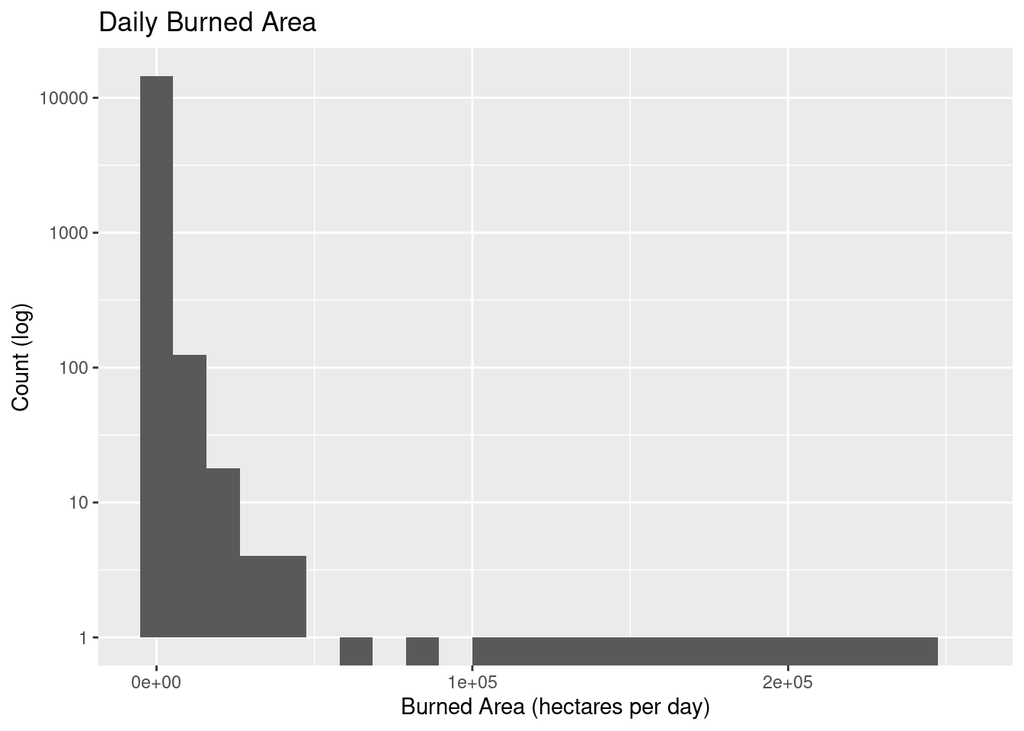

```r
ggplot(wildfire, aes(x = burnt_area)) +
  geom_histogram(bins = 25) +
  scale_y_log10() +
  labs(
    title = "Daily Burned Area",
    x = "Burned Area (hectares per day)",
    y = "Count (log)"
  )
```

The distribution is extremely right-skewed, with a high number of zero values and a small number of extreme fire days. The log transformation helps to clarify with relationship in the data and see the variability.

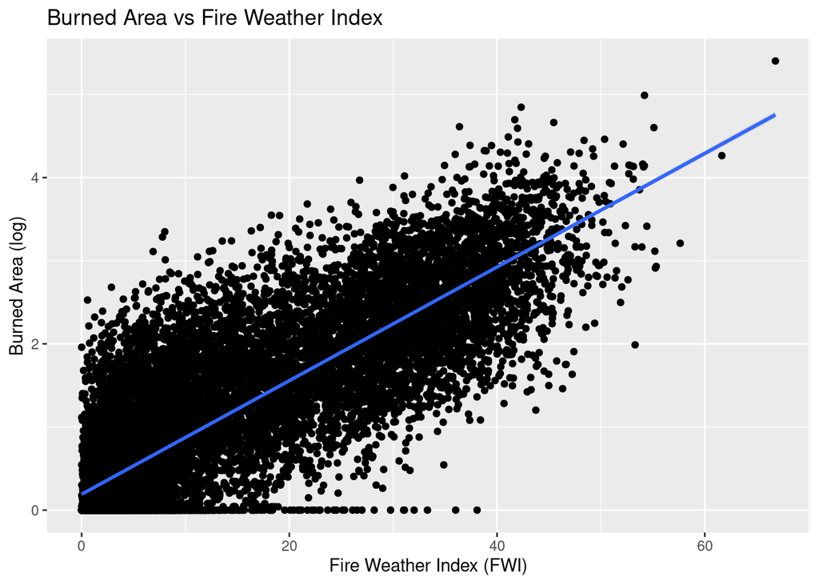

```r
ggplot(wildfire, aes(x = fwi, y = log10(burnt_area +1))) +
  geom_point() +
  geom_smooth(method = "lm") +
  labs(
    title = "Burned Area vs Fire Weather Index",
    x = "Fire Weather Index (FWI)",
    y = "Burned Area (log)"
  )
```

This transformation shows a more linear relationship, which supports the use in regression modeling. We can see a significant relationship between the two variables.

## 3. Possible question and method

From this data, I seek to answer the research question: How do environmental conditions influence the daily total burned area at the national scale?

Supporting Questions:

What is the relationship between FWI and daily burned area? How does ISI affect burned area on active fire days? Does BUI significantly predict the extent of a burned area?

Hypothesized results:

Null hypothesis: Burnt area has no significant relationship with FWI, ISI, BUI, and FFMC

Alternative: Burnt area has a significant relationship with at least one of FWI, ISI, BUI, and FFMC

Methods:

- Confidence Intervals for mean burnt area

```r
t.test(wildfire$burnt_area)
```

```
##
##  One Sample t-test
##
## data:  wildfire$burnt_area
## t = 14.205, df = 14608, p-value < 2.2e-16
## alternative hypothesis: true mean is not equal to 0
## 95 percent confidence interval:
##  280.0369 369.6919
## sample estimates:
## mean of x
##  324.8644
```

This estimates the mean daily burned area, and reveals if it differs significantly from zero.

- Linear Regression/Multiple Linear Regression with model diagnostics

```r
model <- lm(log10(burnt_area +1) ~ fwi + isi + bui + ffmc, data = wildfire)

glance(model)
```

```
## # A tibble: 1 × 12
##   r.squared adj.r.squared sigma statistic p.value    df  logLik    AIC    BIC
##       <dbl>         <dbl> <dbl>     <dbl>   <dbl> <dbl>   <dbl>  <dbl>  <dbl>
## 1     0.728         0.728 0.567     9784.       0     4 -12447. 24906. 24951.
## # ℹ 3 more variables: deviance <dbl>, df.residual <int>, nobs <int>
```

This model evaluates the effects of multiple environmental predictors on the burnt area.